# Supervised Learning - Foundations Project: ReCell

## Problem Statement

### Business Context

Buying and selling used phones and tablets used to be something that happened on a handful of online marketplace sites. But the used and refurbished device market has grown considerably over the past decade, and a new IDC (International Data Corporation) forecast predicts that the used phone market would be worth \$52.7bn by 2023 with a compound annual growth rate (CAGR) of 13.6% from 2018 to 2023. This growth can be attributed to an uptick in demand for used phones and tablets that offer considerable savings compared with new models.

Refurbished and used devices continue to provide cost-effective alternatives to both consumers and businesses that are looking to save money when purchasing one. There are plenty of other benefits associated with the used device market. Used and refurbished devices can be sold with warranties and can also be insured with proof of purchase. Third-party vendors/platforms, such as Verizon, Amazon, etc., provide attractive offers to customers for refurbished devices. Maximizing the longevity of devices through second-hand trade also reduces their environmental impact and helps in recycling and reducing waste. The impact of the COVID-19 outbreak may further boost this segment as consumers cut back on discretionary spending and buy phones and tablets only for immediate needs.

### Objective

The rising potential of this comparatively under-the-radar market fuels the need for an ML-based solution to develop a dynamic pricing strategy for used and refurbished devices. ReCell, a startup aiming to tap the potential in this market, has hired you as a data scientist. They want you to analyze the data provided and build a linear regression model to predict the price of a used phone/tablet and identify factors that significantly influence it.

### Data Description

The data contains the different attributes of used/refurbished phones and tablets. The data was collected in the year 2021. The detailed data dictionary is given below.

- brand_name: Name of manufacturing brand
- os: OS on which the device runs
- screen_size: Size of the screen in cm
- 4g: Whether 4G is available or not
- 5g: Whether 5G is available or not
- main_camera_mp: Resolution of the rear camera in megapixels
- selfie_camera_mp: Resolution of the front camera in megapixels
- int_memory: Amount of internal memory (ROM) in GB
- ram: Amount of RAM in GB
- battery: Energy capacity of the device battery in mAh
- weight: Weight of the device in grams
- release_year: Year when the device model was released
- days_used: Number of days the used/refurbished device has been used
- normalized_new_price: Normalized price of a new device of the same model in euros
- normalized_used_price: Normalized price of the used/refurbished device in euros

## Importing necessary libraries

```python
%load_ext nb_black

import pandas as pd
import numpy as np

# for visualizing data
import matplotlib.pyplot as plt
import seaborn as sns

# For randomized data splitting
from sklearn.model_selection import train_test_split

# To build linear regression_model
import statsmodels.api as sm

# To check model performance
from sklearn.metrics import mean_absolute_error, mean_squared_error, r2_score
```

## Loading the dataset

```python
data = pd.read_csv("used_device_data.csv")
```

## Data Overview

- Observations
- Sanity checks

```python
data.shape
```

```
(3454, 15)
```

```python
data.head()
```

|  | brand_name | os | screen_size | 4g | 5g | main_camera_mp | selfie_camera_mp | int_memory | ram | battery | weight | release_year | days_used | normalized_used_price | normalized_new_price |
| --- | --- | --- | --- | --- | --- | --- | --- | --- | --- | --- | --- | --- | --- | --- | --- |
| 0 | Honor | Android | 14.50 | yes | no | 13.0 | 5.0 | 64.0 | 3.0 | 3020.0 | 146.0 | 2020 | 127 | 4.307572 | 4.715100 |
| 1 | Honor | Android | 17.30 | yes | yes | 13.0 | 16.0 | 128.0 | 8.0 | 4300.0 | 213.0 | 2020 | 325 | 5.162097 | 5.519018 |
| 2 | Honor | Android | 16.69 | yes | yes | 13.0 | 8.0 | 128.0 | 8.0 | 4200.0 | 213.0 | 2020 | 162 | 5.111084 | 5.884631 |
| 3 | Honor | Android | 25.50 | yes | yes | 13.0 | 8.0 | 64.0 | 6.0 | 7250.0 | 480.0 | 2020 | 345 | 5.135387 | 5.630961 |
| 4 | Honor | Android | 15.32 | yes | no | 13.0 | 8.0 | 64.0 | 3.0 | 5000.0 | 185.0 | 2020 | 293 | 4.389995 | 4.947837 |

```python
data.info()
```

```
<class 'pandas.core.frame.DataFrame'>
RangeIndex: 3454 entries, 0 to 3453
Data columns (total 15 columns):
 #   Column                 Non-Null Count  Dtype
---  ------                 --------------  -----
 0   brand_name             3454 non-null   object
 1   os                     3454 non-null   object
 2   screen_size            3454 non-null   float64
 3   4g                     3454 non-null   object
 4   5g                     3454 non-null   object
 5   main_camera_mp         3275 non-null   float64
 6   selfie_camera_mp       3452 non-null   float64
 7   int_memory             3450 non-null   float64
 8   ram                    3450 non-null   float64
 9   battery                3448 non-null   float64
 10  weight                 3447 non-null   float64
 11  release_year           3454 non-null   int64
 12  days_used              3454 non-null   int64
 13  normalized_used_price  3454 non-null   float64
 14  normalized_new_price   3454 non-null   float64
dtypes: float64(9), int64(2), object(4)
memory usage: 404.9+ KB
```

- several variables are of 'object' type that we will change to 'category'

```python
# change 'object' data type to 'category'
for col in data.columns[data.dtypes == "object"]:
    data[col] = data[col].astype("category")
```

```python
data.info()
```

```
<class 'pandas.core.frame.DataFrame'>
RangeIndex: 3454 entries, 0 to 3453
Data columns (total 15 columns):
 #   Column                 Non-Null Count  Dtype
---  ------                 --------------  -----
 0   brand_name             3454 non-null   category
 1   os                     3454 non-null   category
 2   screen_size            3454 non-null   float64
 3   4g                     3454 non-null   category
 4   5g                     3454 non-null   category
 5   main_camera_mp         3275 non-null   float64
 6   selfie_camera_mp       3452 non-null   float64
 7   int_memory             3450 non-null   float64
 8   ram                    3450 non-null   float64
 9   battery                3448 non-null   float64
 10  weight                 3447 non-null   float64
 11  release_year           3454 non-null   int64
 12  days_used              3454 non-null   int64
 13  normalized_used_price  3454 non-null   float64
 14  normalized_new_price   3454 non-null   float64
dtypes: category(4), float64(9), int64(2)
memory usage: 312.2 KB
```

```python
# check for missing values
data.isnull().sum()
```

```
brand_name                 0
os                         0
screen_size                0
4g                         0
5g                         0
main_camera_mp           179
selfie_camera_mp           2
int_memory                 4
ram                        4
battery                    6
weight                     7
release_year               0
days_used                  0
normalized_used_price      0
normalized_new_price       0
dtype: int64
```

- a check for missing values shows several variables that need to be addressed.
- no duplicated values.

```python
# check for duplicates
data.duplicated().sum()
```

```
0
```

```python
# let's view a sample of the data
data.sample(n=10, random_state=1)
```

|  | brand_name | os | screen_size | 4g | 5g | main_camera_mp | selfie_camera_mp | int_memory | ram | battery | weight | release_year | days_used | normalized_used_price | normalized_new_price |
| --- | --- | --- | --- | --- | --- | --- | --- | --- | --- | --- | --- | --- | --- | --- | --- |
| 866 | Others | Android | 15.24 | no | no | 8.00 | 2.0 | 16.0 | 4.00 | 3000.0 | 206.0 | 2014 | 632 | 4.038832 | 5.190788 |
| 957 | Celkon | Android | 10.16 | no | no | 3.15 | 0.3 | 512.0 | 0.25 | 1400.0 | 140.0 | 2013 | 637 | 2.800325 | 3.884652 |
| 280 | Infinix | Android | 15.39 | yes | no | NaN | 8.0 | 32.0 | 2.00 | 5000.0 | 185.0 | 2020 | 329 | 4.370713 | 4.487287 |
| 2150 | Oppo | Android | 12.83 | yes | no | 13.00 | 16.0 | 64.0 | 4.00 | 3200.0 | 148.0 | 2017 | 648 | 4.677863 | 5.639422 |
| 93 | LG | Android | 15.29 | yes | no | 13.00 | 5.0 | 32.0 | 3.00 | 3500.0 | 179.0 | 2019 | 216 | 4.517650 | 5.300415 |
| 1040 | Gionee | Android | 12.83 | yes | no | 13.00 | 8.0 | 32.0 | 4.00 | 3150.0 | 166.0 | 2016 | 970 | 4.645640 | 5.634325 |
| 3170 | ZTE | Others | 10.16 | no | no | 3.15 | 5.0 | 16.0 | 4.00 | 1400.0 | 125.0 | 2014 | 1007 | 3.764451 | 4.244344 |
| 2742 | Sony | Android | 12.70 | yes | no | 20.70 | 2.0 | 16.0 | 4.00 | 3000.0 | 170.0 | 2013 | 1060 | 4.422809 | 5.799820 |
| 102 | Meizu | Android | 15.29 | yes | no | NaN | 20.0 | 128.0 | 6.00 | 3600.0 | 165.0 | 2019 | 332 | 4.959412 | 6.040659 |
| 1195 | HTC | Android | 10.29 | no | no | 8.00 | 2.0 | 32.0 | 4.00 | 2000.0 | 146.0 | 2015 | 892 | 4.227855 | 4.879007 |

## Exploratory Data Analysis (EDA)

- EDA is an important part of any project involving data.
- It is important to investigate and understand the data better before building a model with it.
- A few questions have been mentioned below which will help you approach the analysis in the right manner and generate insights from the data.
- A thorough analysis of the data, in addition to the questions mentioned below, should be done.

**Questions**:

1. What does the distribution of normalized used device prices look like?
2. What percentage of the used device market is dominated by Android devices?
3. The amount of RAM is important for the smooth functioning of a device. How does the amount of RAM vary with the brand?
4. A large battery often increases a device's weight, making it feel uncomfortable in the hands. How does the weight vary for phones and tablets offering large batteries (more than 4500 mAh)?
5. Bigger screens are desirable for entertainment purposes as they offer a better viewing experience. How many phones and tablets are available across different brands with a screen size larger than 6 inches?
6. A lot of devices nowadays offer great selfie cameras, allowing us to capture our favorite moments with loved ones. What is the distribution of devices offering greater than 8MP selfie cameras across brands?
7. Which attributes are highly correlated with the normalized price of a used device?

```python
data.describe(include="all").T
```

|  | count | unique | top | freq | mean | std | min | 25% | 50% | 75% | max |
| --- | --- | --- | --- | --- | --- | --- | --- | --- | --- | --- | --- |
| brand_name | 3454 | 34 | Others | 502 | NaN | NaN | NaN | NaN | NaN | NaN | NaN |
| os | 3454 | 4 | Android | 3214 | NaN | NaN | NaN | NaN | NaN | NaN | NaN |
| screen_size | 3454.0 | NaN | NaN | NaN | 13.713115 | 3.80528 | 5.08 | 12.7 | 12.83 | 15.34 | 30.71 |
| 4g | 3454 | 2 | yes | 2335 | NaN | NaN | NaN | NaN | NaN | NaN | NaN |
| 5g | 3454 | 2 | no | 3302 | NaN | NaN | NaN | NaN | NaN | NaN | NaN |
| main_camera_mp | 3275.0 | NaN | NaN | NaN | 9.460208 | 4.815461 | 0.08 | 5.0 | 8.0 | 13.0 | 48.0 |
| selfie_camera_mp | 3452.0 | NaN | NaN | NaN | 6.554229 | 6.970372 | 0.0 | 2.0 | 5.0 | 8.0 | 32.0 |
| int_memory | 3450.0 | NaN | NaN | NaN | 54.573099 | 84.972371 | 0.01 | 16.0 | 32.0 | 64.0 | 1024.0 |
| ram | 3450.0 | NaN | NaN | NaN | 4.036122 | 1.365105 | 0.02 | 4.0 | 4.0 | 4.0 | 12.0 |
| battery | 3448.0 | NaN | NaN | NaN | 3133.402697 | 1299.682844 | 500.0 | 2100.0 | 3000.0 | 4000.0 | 9720.0 |
| weight | 3447.0 | NaN | NaN | NaN | 182.751871 | 88.413228 | 69.0 | 142.0 | 160.0 | 185.0 | 855.0 |
| release_year | 3454.0 | NaN | NaN | NaN | 2015.965258 | 2.298455 | 2013.0 | 2014.0 | 2015.5 | 2018.0 | 2020.0 |
| days_used | 3454.0 | NaN | NaN | NaN | 674.869716 | 248.580166 | 91.0 | 533.5 | 690.5 | 868.75 | 1094.0 |
| normalized_used_price | 3454.0 | NaN | NaN | NaN | 4.364712 | 0.588914 | 1.536867 | 4.033931 | 4.405133 | 4.7557 | 6.619433 |
| normalized_new_price | 3454.0 | NaN | NaN | NaN | 5.233107 | 0.683637 | 2.901422 | 4.790342 | 5.245892 | 5.673718 | 7.847841 |

```python
# fix the missing values
# we first create a copy of the original data to avoid changes to it
data = data.copy()
```

```python
# dropping missing values in the target
data.dropna(subset=["normalized_used_price"], inplace=True)
```

```python
# filling missing values using the column median for the predictor variables
medianFiller = lambda x: x.fillna(x.median())
numeric_columns = data.select_dtypes(include=np.number).columns.tolist()
data[numeric_columns] = data[numeric_columns].apply(medianFiller, axis=0)
```

```python
data.isnull().sum()
```

```
brand_name               0
os                       0
screen_size              0
4g                       0
5g                       0
main_camera_mp           0
selfie_camera_mp         0
int_memory               0
ram                      0
battery                  0
weight                   0
release_year             0
days_used                0
normalized_used_price    0
normalized_new_price     0
dtype: int64
```

- used the median to fill in missing values for each variable respectively.

```python
# check the number of unique values in each column of the dataframe
data.nunique()
```

```
brand_name                 34
os                          4
screen_size               142
4g                          2
5g                          2
main_camera_mp             41
selfie_camera_mp           37
int_memory                 15
ram                        12
battery                   324
weight                    555
release_year                8
days_used                 924
normalized_used_price    3094
normalized_new_price     2988
dtype: int64
```

```python
data.brand_name.value_counts()
```

```
Others        502
Samsung       341
Huawei        251
LG            201
Lenovo        171
ZTE           140
Xiaomi        132
Oppo          129
Asus          122
Alcatel       121
Vivo          117
Micromax      117
Honor         116
HTC           110
Nokia         106
Motorola      106
Sony           86
Meizu          62
Gionee         56
Acer           51
XOLO           49
Panasonic      47
Realme         41
Apple          39
Lava           36
Celkon         33
Spice          30
Karbonn        29
Microsoft      22
OnePlus        22
Coolpad        22
BlackBerry     22
Google         15
Infinix        10
Name: brand_name, dtype: int64
```

- there are significant number of brands that make cell phones

```python
def histogram_boxplot(data, feature, figsize=(12, 7), kde=False, bins=None):
    """
    Boxplot and histogram combined

    data: dataframe
    feature: dataframe column
    figsize: size of figure (default (12,7))
    kde: whether to show the density curve (default False)
    bins: number of bins for histogram (default None)
    """
    f2, (ax_box2, ax_hist2) = plt.subplots(
        nrows=2,  # Number of rows of the subplot grid= 2
        sharex=True,  # x-axis will be shared among all subplots
        gridspec_kw={"height_ratios": (0.25, 0.75)},
        figsize=figsize,
    )  # creating the 2 subplots
    sns.boxplot(
        data=data, x=feature, ax=ax_box2, showmeans=True, color="violet"
    )  # boxplot will be created and a star will indicate the mean value of the column
    sns.histplot(
        data=data, x=feature, kde=kde, ax=ax_hist2, bins=bins, palette="winter"
    ) if bins else sns.histplot(
        data=data, x=feature, kde=kde, ax=ax_hist2
    )  # For histogram
    ax_hist2.axvline(
        data[feature].mean(), color="green", linestyle="--"
    )  # Add mean to the histogram
    ax_hist2.axvline(
        data[feature].median(), color="black", linestyle="-"
    )  # Add median to the histogram

# function to create labeled barplots


def labeled_barplot(data, feature, perc=False, n=None):
    """
    Barplot with percentage at the top

    data: dataframe
    feature: dataframe column
    perc: whether to display percentages instead of count (default is False)
    n: displays the top n category levels (default is None, i.e., display all levels)
    """

    total = len(data[feature])  # length of the column
    count = data[feature].nunique()
    if n is None:
        plt.figure(figsize=(count + 1, 5))
    else:
        plt.figure(figsize=(n + 1, 5))

    plt.xticks(rotation=90, fontsize=15)
    ax = sns.countplot(
        data=data,
        x=feature,
        palette="Paired",
        order=data[feature].value_counts().index[:n].sort_values(),
    )

    for p in ax.patches:
        if perc == True:
            label = "{:.1f}%".format(
                100 * p.get_height() / total
            )  # percentage of each class of the category
        else:
            label = p.get_height()  # count of each level of the category

        x = p.get_x() + p.get_width() / 2  # width of the plot
        y = p.get_height()  # height of the plot

        ax.annotate(
            label,
            (x, y),
            ha="center",
            va="center",
            size=12,
            xytext=(0, 5),
            textcoords="offset points",
        )  # annotate the percentage

    plt.show()  # show the plot
```

## 1. Distribution normalized used device prices

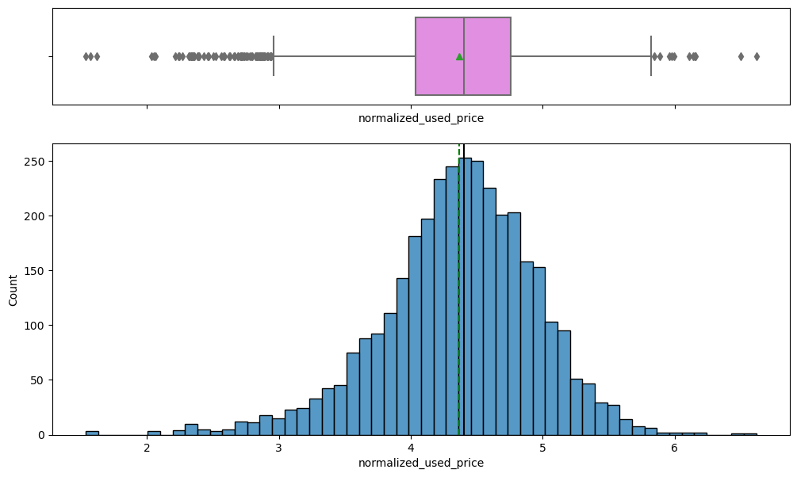

```python
# no. 1 distribution of normalized used device prices


histogram_boxplot(data, "normalized_used_price")
```

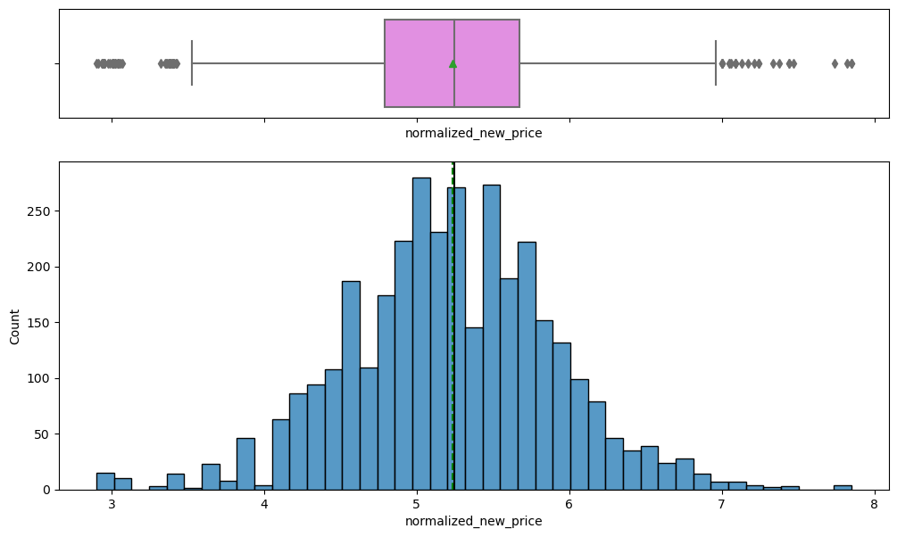

```python
histogram_boxplot(data, "normalized_new_price")
```

- both new and used prices are approximately normally distributed

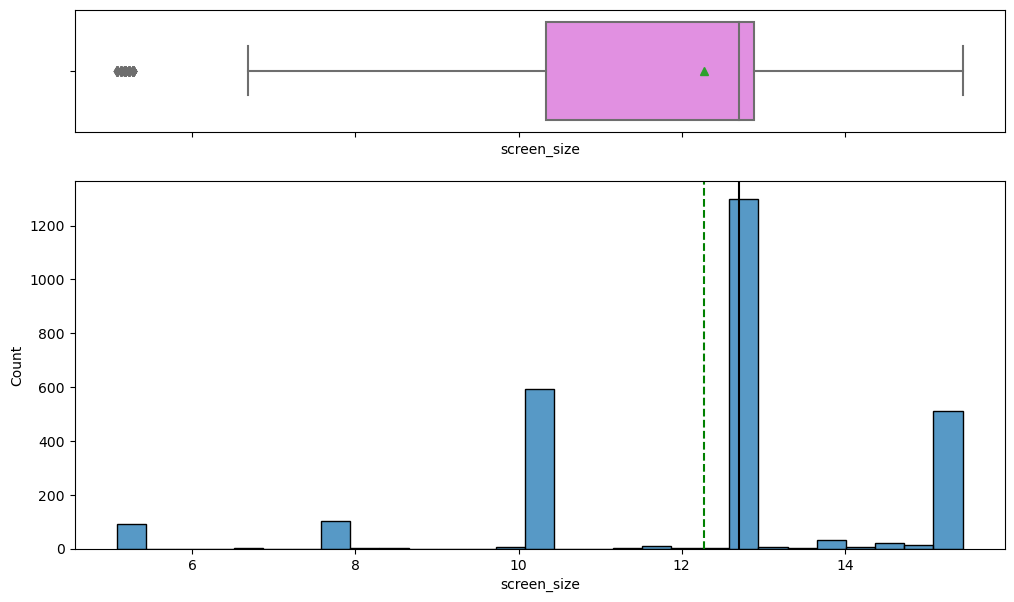

```python
screen_size_under_1545 = data[data.screen_size < 15.45]
histogram_boxplot(screen_size_under_1545, "screen_size")
```

- some very small screen sizes create left skew in the screen size data

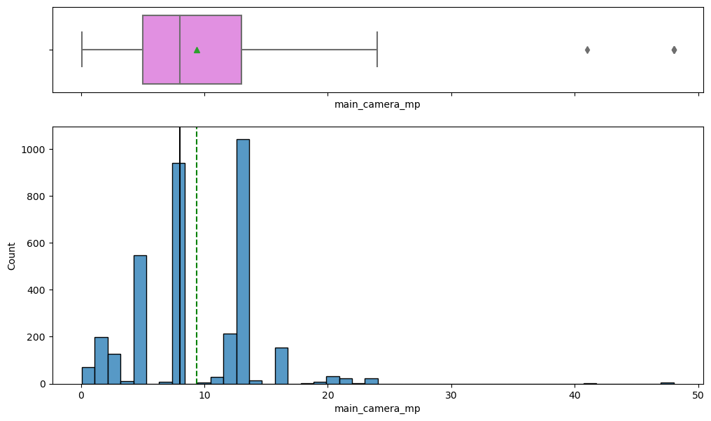

```python
histogram_boxplot(data, "main_camera_mp")
```

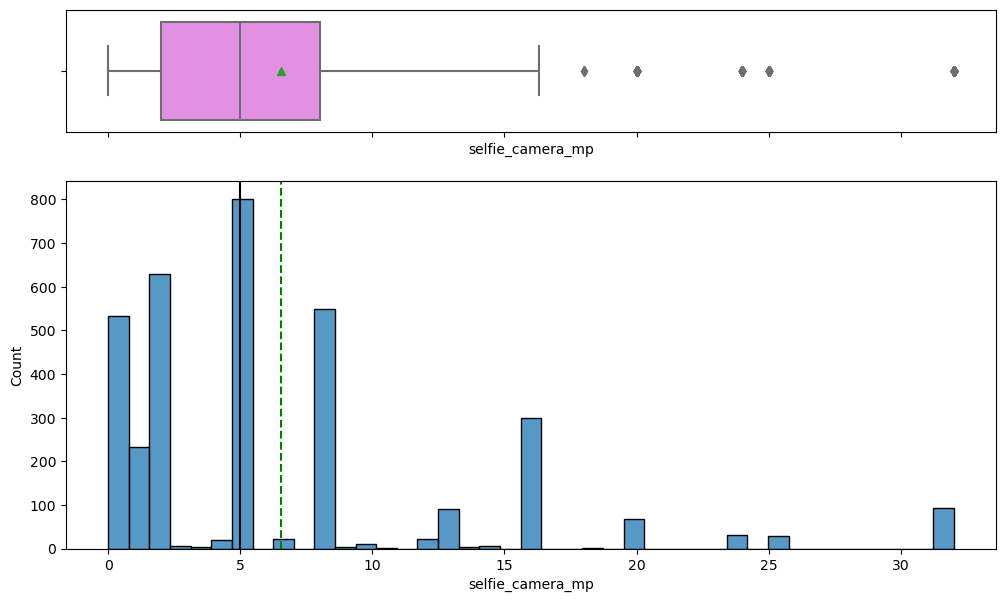

```python
histogram_boxplot(data, "selfie_camera_mp")
```

- both the main and selfie camera data is a little skewed to the right due to some very large megapixel models.

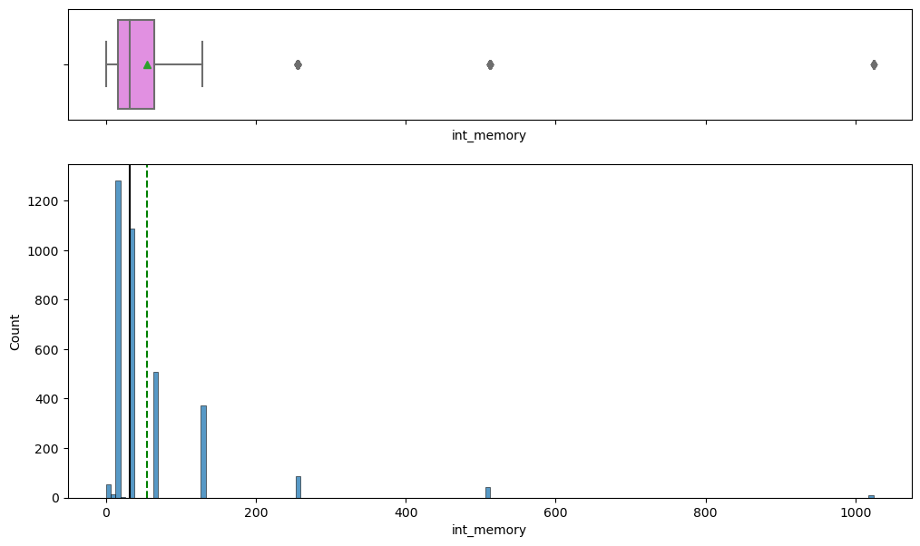

```python
histogram_boxplot(data, "int_memory")
```

- internal memory skewed right due to a few large outliers

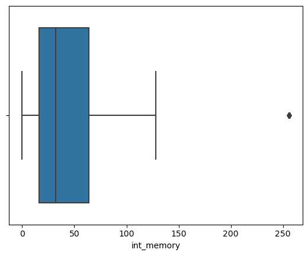

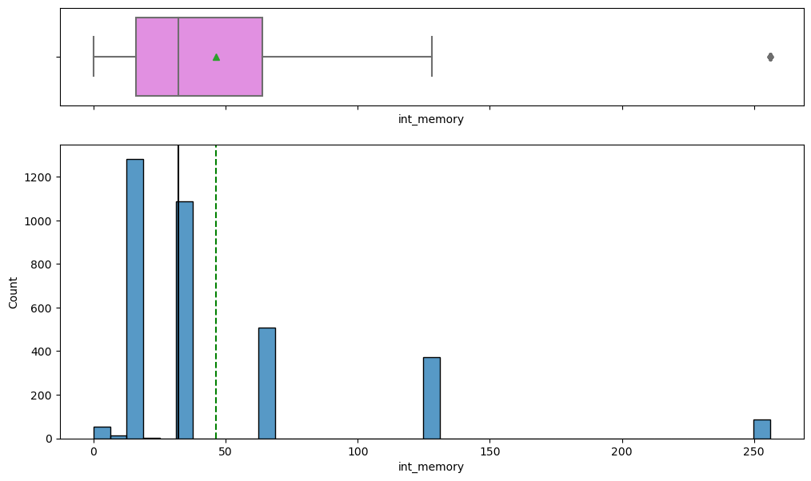

```python
# drop int_memory greater than 400 - outlier treatment
data_mem = data.copy()
data_mem = data_mem[data.int_memory < 400]
sns.boxplot(data=data_mem, x="int_memory")


histogram_boxplot(data_mem, "int_memory")
```

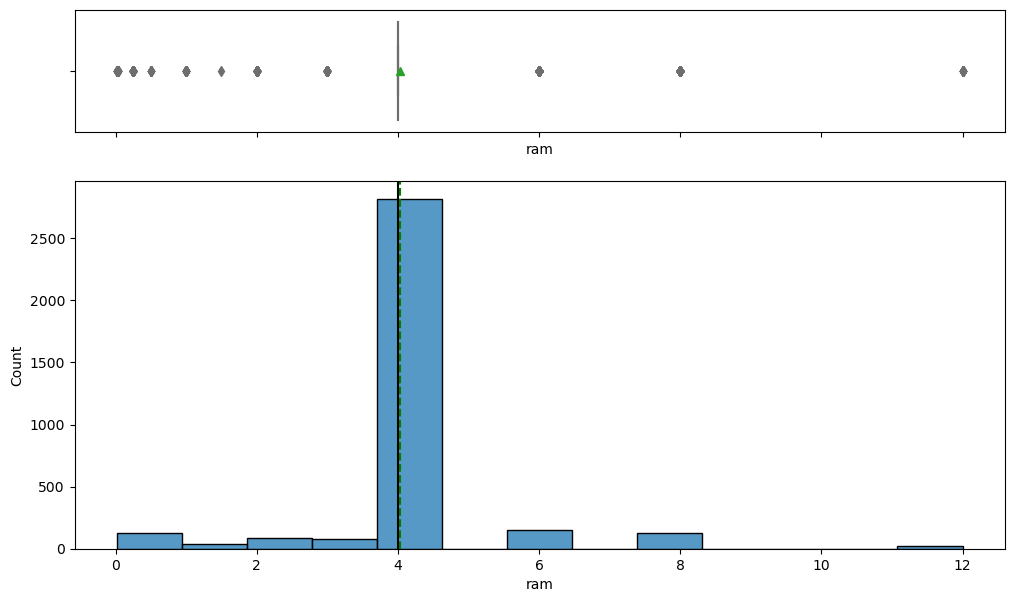

```python
histogram_boxplot(data, "ram")
```

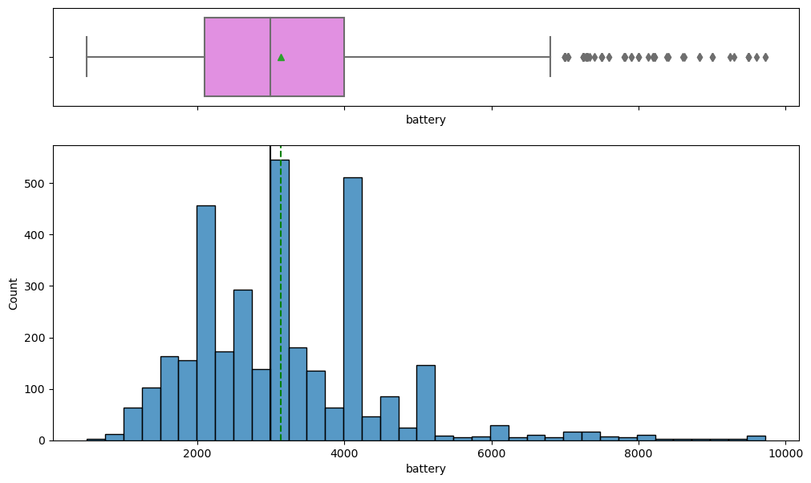

```python
histogram_boxplot(data, "battery")
```

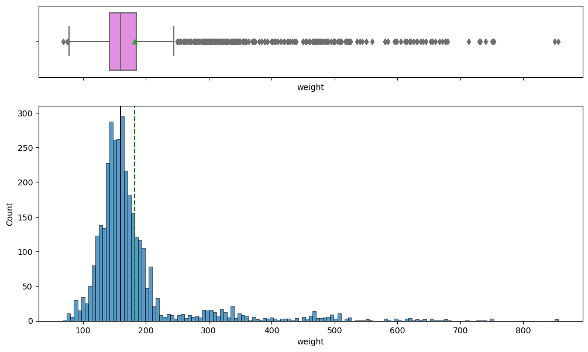

```python
histogram_boxplot(data, "weight")
```

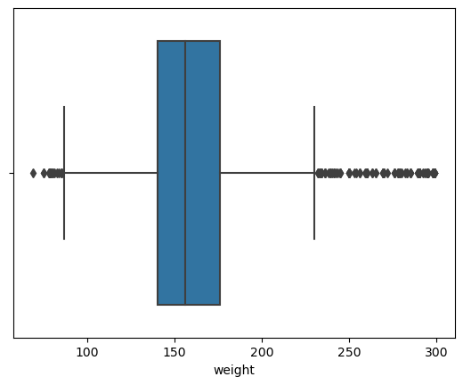

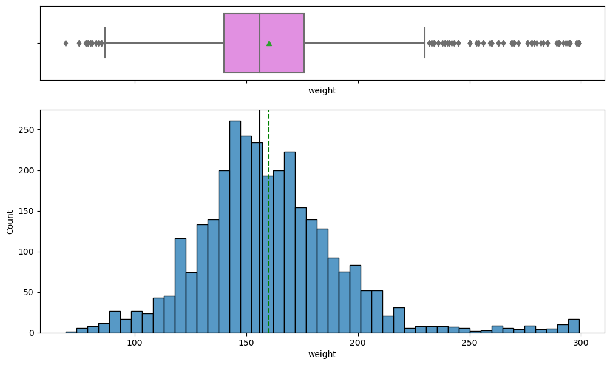

```python
# drop weight greater than 300 - outlier treatment
data_weight = data.copy()
data_weight = data_weight[data.weight < 300]
sns.boxplot(data=data_weight, x="weight")


histogram_boxplot(data_weight, "weight")
```

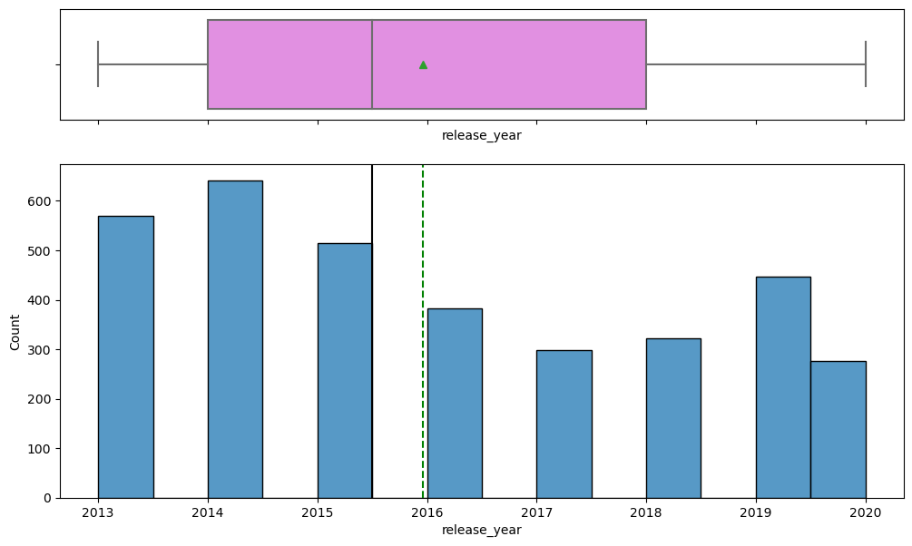

```python
histogram_boxplot(data, "release_year")
```

- as we would probably guess, the older models are the ones most available on the resale market.

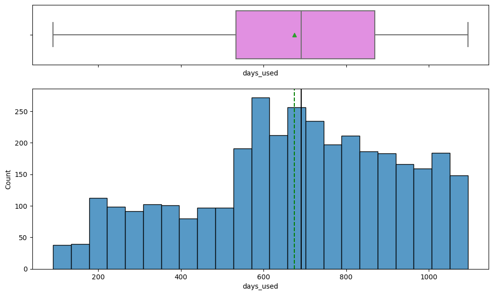

```python
histogram_boxplot(data, "days_used")
```

- the number of days used could be difficult to interpret without making too many assumption. Looking at days used with the year released would be helpful. As it is, the assumption would be that the older the phone, the more days used it will have on it.

## 2. A look at the percentage of the device market for Android

```python
from collections import Counter
count_of_os = Counter(data['os'])

print(count_of_os)
```

```
Counter({'Android': 3214, 'Others': 137, 'Windows': 67, 'iOS': 36})
```

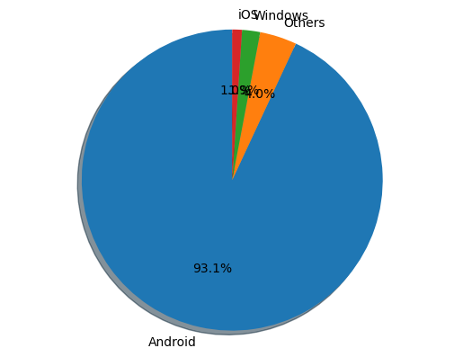

```python
# 2 percentage of device market for Android
labels = 'Android', 'Others', "Windows", 'iOS'
sizes = [3214, 137, 67, 36]

fig1, ax1 = plt.subplots()
ax1.pie(sizes, labels=labels, autopct='%1.1f%%', shadow=True, startangle=90)
ax1.axis('equal')

plt.show()
```

- Missing value treatment
- Feature engineering (if needed)
- Outlier detection and treatment (if needed)
- Preparing data for modeling
- Any other preprocessing steps (if needed)

## 3. RAM by brand

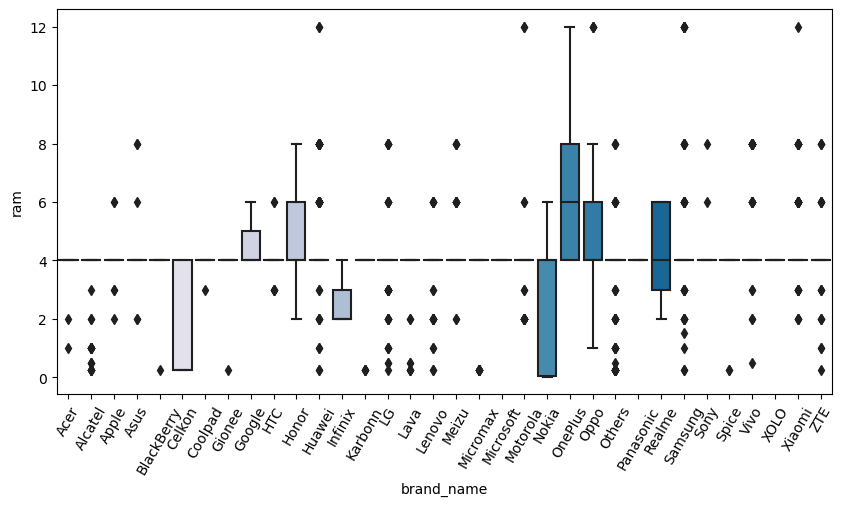

```python
# 3 RAM by brand

plt.figure(figsize=(10,5))
sns.boxplot(x = "brand_name", y = "ram", data = data, palette = 'PuBu')
plt.xticks(rotation = 60)
plt.show()
```

- brands tend to vary quite a bit by what they offer in terms of RAM. Some offer from very little to over 8 GB, while others stick to a tighter range such as 3-6 GB.

## 4. How weight varies by battery sizes greater than 4500 mAh

```python
q = data[data.battery > 4500]
q.count()
```

```
brand_name               341
os                       341
screen_size              341
4g                       341
5g                       341
main_camera_mp           341
selfie_camera_mp         341
int_memory               341
ram                      341
battery                  341
weight                   341
release_year             341
days_used                341
normalized_used_price    341
normalized_new_price     341
dtype: int64
```

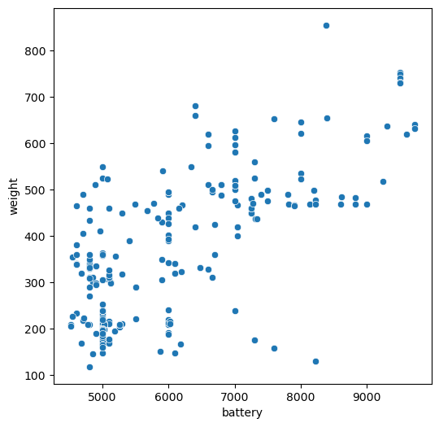

```python
# 4 weight vary by battery sizes greater than 4500 mAh

q = data[data.battery > 4500]
plt.figure(figsize=(6, 6))
sns.scatterplot(data=q, x= 'battery', y="weight")
plt.show()
```

- there is a general positive correlation where the more capacity of the battery, the heavier the batter will be.

## 5. How many devices with screen size > 6 inches (15.24 cm) across brands

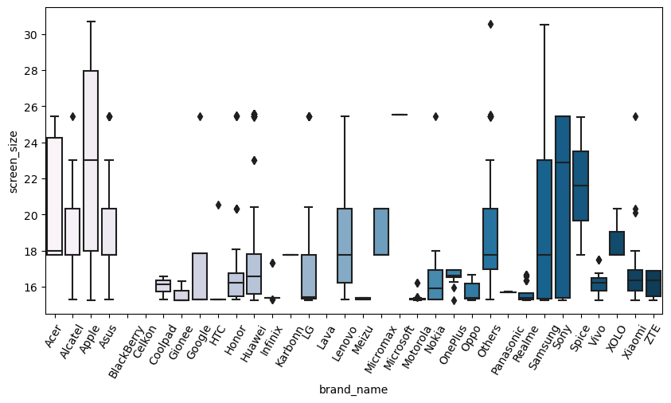

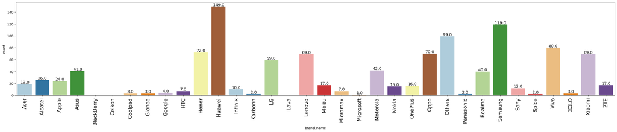

```python
# 5 how many devices with screen size > 6 inches (15.24 cm) across brands

w = data[data.screen_size > 15.24]

plt.figure(figsize=(10, 5))
sns.boxplot(x="brand_name", y="screen_size", data=w, palette="PuBu")
plt.xticks(rotation=60)
plt.show()

labeled_barplot(w, "brand_name")
```

- many brands offer screen sizes greater than 6 inches, but Huawei and Samsung offer the most.

## 6. Devices offering greater than 8 mp selfie feature across brands

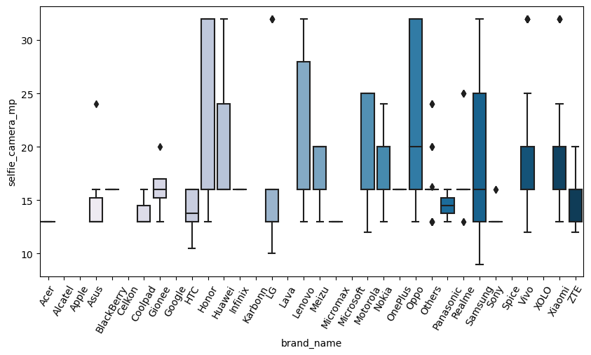

[figure not shown]

```python
# 6 devices offering > 8MP selfie feature across brands

t = data[data.selfie_camera_mp > 8]

plt.figure(figsize=(10,5))
sns.boxplot(x = "brand_name", y = "selfie_camera_mp", data = t, palette = 'PuBu')
plt.xticks(rotation = 60)
plt.show()

labeled_barplot(w, 'brand_name')
```

## EDA

- It is a good idea to explore the data once again after manipulating it.

```python
data.describe()
```

|  | screen_size | main_camera_mp | selfie_camera_mp | int_memory | ram | battery | weight | release_year | days_used | normalized_used_price | normalized_new_price |
| --- | --- | --- | --- | --- | --- | --- | --- | --- | --- | --- | --- |
| count | 3454.000000 | 3454.000000 | 3454.000000 | 3454.000000 | 3454.000000 | 3454.000000 | 3454.000000 | 3454.000000 | 3454.000000 | 3454.000000 | 3454.000000 |
| mean | 13.713115 | 9.384534 | 6.553329 | 54.546957 | 4.036080 | 3133.170961 | 182.705761 | 2015.965258 | 674.869716 | 4.364712 | 5.233107 |
| std | 3.805280 | 4.700148 | 6.968453 | 84.926611 | 1.364314 | 1298.565062 | 88.329494 | 2.298455 | 248.580166 | 0.588914 | 0.683637 |
| min | 5.080000 | 0.080000 | 0.000000 | 0.010000 | 0.020000 | 500.000000 | 69.000000 | 2013.000000 | 91.000000 | 1.536867 | 2.901422 |
| 25% | 12.700000 | 5.000000 | 2.000000 | 16.000000 | 4.000000 | 2100.000000 | 142.000000 | 2014.000000 | 533.500000 | 4.033931 | 4.790342 |
| 50% | 12.830000 | 8.000000 | 5.000000 | 32.000000 | 4.000000 | 3000.000000 | 160.000000 | 2015.500000 | 690.500000 | 4.405133 | 5.245892 |
| 75% | 15.340000 | 13.000000 | 8.000000 | 64.000000 | 4.000000 | 4000.000000 | 185.000000 | 2018.000000 | 868.750000 | 4.755700 | 5.673718 |
| max | 30.710000 | 48.000000 | 32.000000 | 1024.000000 | 12.000000 | 9720.000000 | 855.000000 | 2020.000000 | 1094.000000 | 6.619433 | 7.847841 |

```python
data.shape
```

```
(3454, 15)
```

```python
data1 = data.copy()
```

## Bivariate Analysis

```python
# correlation of all attributes with normalized_used_price
data[data.columns[:]].corr()["normalized_used_price"][:]
```

```
screen_size              0.614785
main_camera_mp           0.552477
selfie_camera_mp         0.607548
int_memory               0.190954
ram                      0.518783
battery                  0.612041
weight                   0.382456
release_year             0.509790
days_used               -0.358264
normalized_used_price    1.000000
normalized_new_price     0.834496
Name: normalized_used_price, dtype: float64
```

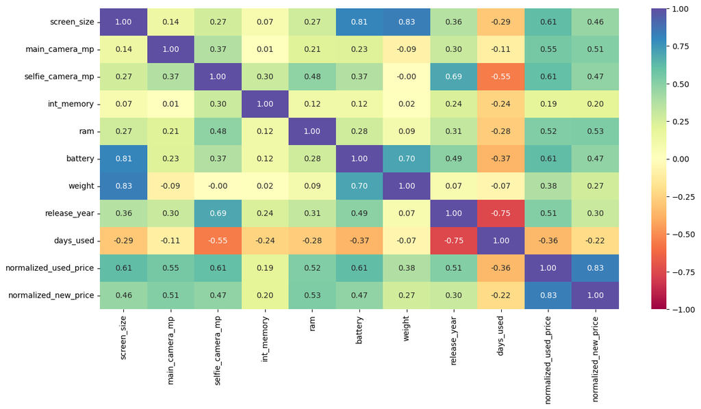

```python
numeric_columns = data.select_dtypes(include=np.number).columns.tolist()

# correlation heatmap
plt.figure(figsize=(15, 7))
sns.heatmap(
    data[numeric_columns].corr(),
    annot=True,
    vmin=-1,
    vmax=1,
    fmt=".2f",
    cmap="Spectral",
)
plt.show()
```

- screen size, battery and weight all have high correlations

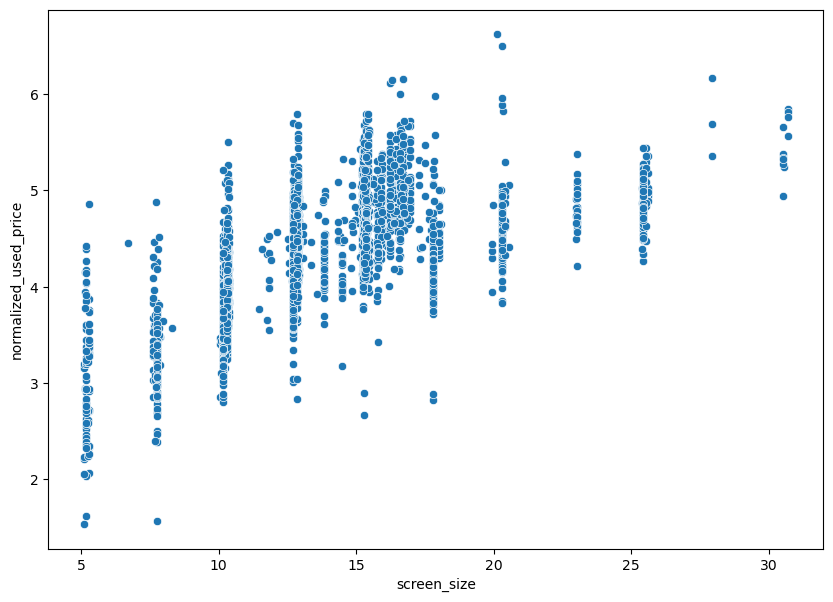

```python
plt.figure(figsize=(10, 7))
sns.scatterplot(y="normalized_used_price", x="screen_size",  data=data)
plt.show()
```

- screen size appears to be a driver of used price

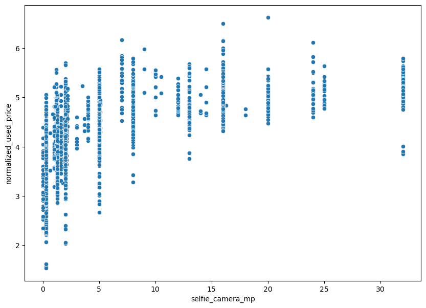

```python
plt.figure(figsize=(10, 7))
sns.scatterplot(y="normalized_used_price", x="selfie_camera_mp",  data=data)
plt.show()
```

- the mega pixel offering for a selfie camera feature is a positive driver of used price.

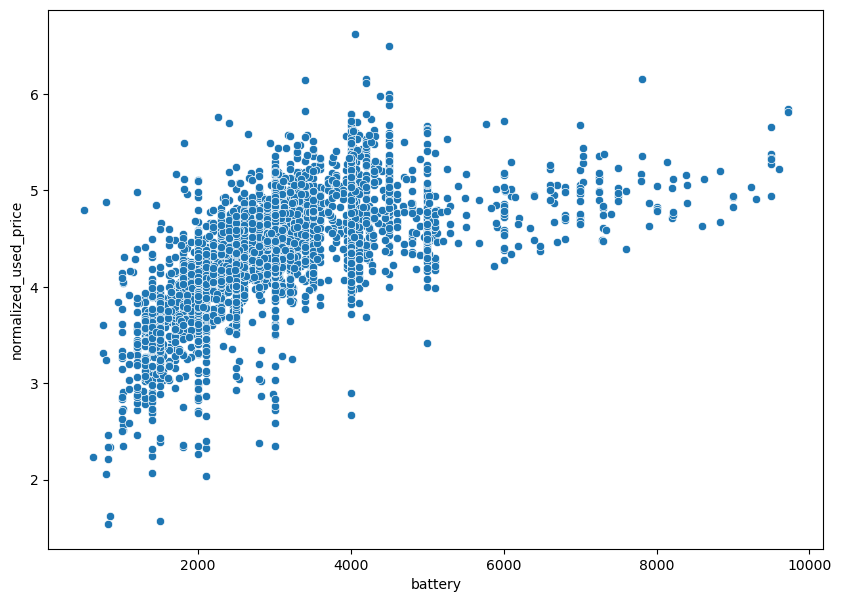

```python
plt.figure(figsize=(10, 7))
sns.scatterplot(y="normalized_used_price", x="battery",  data=data)
plt.show()
```

- the more battery capacity leads to a higher used price, generally

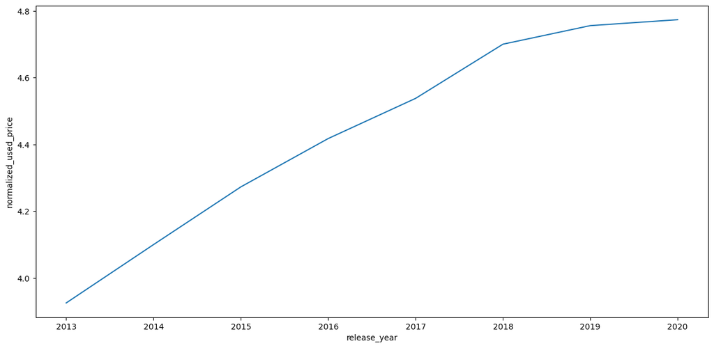

```python
# average life expectancy over the years
plt.figure(figsize=(15, 7))
sns.lineplot(x="release_year", y="normalized_used_price", data=data, ci=None)
plt.show()
```

- a more recently released phone will command higher used prices

## Model Building - Linear Regression

1. We want to predict the used cell phone prices.
2. Before we proceed to build a model, we'll have to encode categorical features.
3. We'll split the data into train and test to be able to evaluate the model that we build on the train data.
4. We will build a Linear Regression model using the train data and then check it's performance.

```python
# define the X ad y variables.
X = data.drop(["normalized_used_price"], axis=1)
y = data["normalized_used_price"]

print(X.head())
print(y.head())
```

```
  brand_name       os  screen_size   4g   5g  main_camera_mp  \
0      Honor  Android        14.50  yes   no            13.0
1      Honor  Android        17.30  yes  yes            13.0
2      Honor  Android        16.69  yes  yes            13.0
3      Honor  Android        25.50  yes  yes            13.0
4      Honor  Android        15.32  yes   no            13.0

   selfie_camera_mp  int_memory  ram  battery  weight  release_year  \
0               5.0        64.0  3.0   3020.0   146.0          2020
1              16.0       128.0  8.0   4300.0   213.0          2020
2               8.0       128.0  8.0   4200.0   213.0          2020
3               8.0        64.0  6.0   7250.0   480.0          2020
4               8.0        64.0  3.0   5000.0   185.0          2020

   days_used  normalized_new_price
0        127              4.715100
1        325              5.519018
2        162              5.884631
3        345              5.630961
4        293              4.947837
0    4.307572
1    5.162097
2    5.111084
3    5.135387
4    4.389995
Name: normalized_used_price, dtype: float64
```

```python
# add constant which is the y-intercept when X-values are all 0.
X = sm.add_constant(X)
```

```python
# get dummy values for categorical variables
X = pd.get_dummies(
    X,
    columns=X.select_dtypes(include=["category"]).columns.tolist(),
    drop_first=True,
)
X.head()
```

|  | const | screen_size | main_camera_mp | selfie_camera_mp | int_memory | ram | battery | weight | release_year | days_used | ... | brand_name_Spice | brand_name_Vivo | brand_name_XOLO | brand_name_Xiaomi | brand_name_ZTE | os_Others | os_Windows | os_iOS | 4g_yes | 5g_yes |
| --- | --- | --- | --- | --- | --- | --- | --- | --- | --- | --- | --- | --- | --- | --- | --- | --- | --- | --- | --- | --- | --- |
| 0 | 1.0 | 14.50 | 13.0 | 5.0 | 64.0 | 3.0 | 3020.0 | 146.0 | 2020 | 127 | ... | 0 | 0 | 0 | 0 | 0 | 0 | 0 | 0 | 1 | 0 |
| 1 | 1.0 | 17.30 | 13.0 | 16.0 | 128.0 | 8.0 | 4300.0 | 213.0 | 2020 | 325 | ... | 0 | 0 | 0 | 0 | 0 | 0 | 0 | 0 | 1 | 1 |
| 2 | 1.0 | 16.69 | 13.0 | 8.0 | 128.0 | 8.0 | 4200.0 | 213.0 | 2020 | 162 | ... | 0 | 0 | 0 | 0 | 0 | 0 | 0 | 0 | 1 | 1 |
| 3 | 1.0 | 25.50 | 13.0 | 8.0 | 64.0 | 6.0 | 7250.0 | 480.0 | 2020 | 345 | ... | 0 | 0 | 0 | 0 | 0 | 0 | 0 | 0 | 1 | 1 |
| 4 | 1.0 | 15.32 | 13.0 | 8.0 | 64.0 | 3.0 | 5000.0 | 185.0 | 2020 | 293 | ... | 0 | 0 | 0 | 0 | 0 | 0 | 0 | 0 | 1 | 0 |

5 rows × 49 columns

```python
# splitting the data in 70:30 ratio for train to test data

x_train, x_test, y_train, y_test = train_test_split(X, y, test_size=0.3, random_state=1)
```

```python
print("Number of rows in train data =", x_train.shape[0])
print("Number of rows in test data =", x_test.shape[0])
```

```
Number of rows in train data = 2417
Number of rows in test data = 1037
```

```python
olsmodel = sm.OLS(y_train, x_train).fit()
print(olsmodel.summary())
```

```
                              OLS Regression Results
=================================================================================
Dep. Variable:     normalized_used_price   R-squared:                       0.845
Model:                               OLS   Adj. R-squared:                  0.842
Method:                    Least Squares   F-statistic:                     268.8
Date:                   Fri, 10 Feb 2023   Prob (F-statistic):               0.00
Time:                           18:13:29   Log-Likelihood:                 124.22
No. Observations:                   2417   AIC:                            -150.4
Df Residuals:                       2368   BIC:                             133.3
Df Model:                             48
Covariance Type:               nonrobust
=========================================================================================
                            coef    std err          t      P>|t|      [0.025      0.975]
-----------------------------------------------------------------------------------------
const                   -48.6977      9.184     -5.303      0.000     -66.707     -30.689
screen_size               0.0243      0.003      7.145      0.000       0.018       0.031
main_camera_mp            0.0203      0.001     13.806      0.000       0.017       0.023
selfie_camera_mp          0.0136      0.001     12.084      0.000       0.011       0.016
int_memory                0.0001   6.97e-05      1.542      0.123   -2.92e-05       0.000
ram                       0.0239      0.005      4.657      0.000       0.014       0.034
battery               -1.585e-05   7.27e-06     -2.181      0.029   -3.01e-05    -1.6e-06
weight                    0.0010      0.000      7.421      0.000       0.001       0.001
release_year              0.0248      0.005      5.441      0.000       0.016       0.034
days_used              3.485e-05   3.09e-05      1.127      0.260   -2.58e-05    9.55e-05
normalized_new_price      0.4310      0.012     35.133      0.000       0.407       0.455
brand_name_Alcatel        0.0153      0.048      0.321      0.748      -0.078       0.109
brand_name_Apple         -0.0116      0.147     -0.079      0.937      -0.300       0.277
brand_name_Asus           0.0195      0.048      0.408      0.683      -0.074       0.113
brand_name_BlackBerry    -0.0295      0.070     -0.420      0.675      -0.167       0.108
brand_name_Celkon        -0.0424      0.066     -0.640      0.522      -0.172       0.088
brand_name_Coolpad        0.0401      0.073      0.551      0.582      -0.103       0.183
brand_name_Gionee         0.0454      0.058      0.787      0.431      -0.068       0.159
brand_name_Google        -0.0312      0.085     -0.369      0.712      -0.197       0.135
brand_name_HTC           -0.0115      0.048     -0.240      0.811      -0.106       0.083
brand_name_Honor          0.0244      0.049      0.496      0.620      -0.072       0.121
brand_name_Huawei        -0.0081      0.044     -0.181      0.856      -0.095       0.079
brand_name_Infinix        0.1548      0.093      1.661      0.097      -0.028       0.337
brand_name_Karbonn        0.0971      0.067      1.447      0.148      -0.034       0.229
brand_name_LG            -0.0152      0.045     -0.335      0.738      -0.104       0.074
brand_name_Lava           0.0337      0.062      0.541      0.589      -0.089       0.156
```

[output cut: 19 more lines]

```
os_Windows               -0.0176      0.045     -0.389      0.697      -0.106       0.071
os_iOS                   -0.0585      0.146     -0.399      0.690      -0.346       0.229
4g_yes                    0.0507      0.016      3.190      0.001       0.020       0.082
5g_yes                   -0.0435      0.032     -1.369      0.171      -0.106       0.019
==============================================================================
Omnibus:                      217.620   Durbin-Watson:                   1.904
Prob(Omnibus):                  0.000   Jarque-Bera (JB):              409.702
Skew:                          -0.607   Prob(JB):                     1.08e-89
Kurtosis:                       4.611   Cond. No.                     7.69e+06
==============================================================================

Notes:
[1] Standard Errors assume that the covariance matrix of the errors is correctly specified.
[2] The condition number is large, 7.69e+06. This might indicate that there are
strong multicollinearity or other numerical problems.
```

Adjusted R-squared = .842 which is a very good value.

Const coefficient = -48.6977 This is the y-intercept

To check performance of the model using different metrics:

- We will be using metric functions defined in sklearn for RMSE, MAE, and R^2.

```python
x_train1 = sm.add_constant(x_train)
# adding constant to the test data
x_test1 = sm.add_constant(x_test)

olsmod0 = sm.OLS(y_train, x_train1).fit()
print(olsmod0.summary())
```

[output not shown]

## Model Performance Check

```python
# function to compute adjusted R-squared
def adj_r2_score(predictors, targets, predictions):
    r2 = r2_score(targets, predictions)
    n = predictors.shape[0]
    k = predictors.shape[1]
    return 1 - ((1 - r2) * (n - 1) / (n - k - 1))


# function to compute MAPE
def mape_score(targets, predictions):
    return np.mean(np.abs(targets - predictions) / targets) * 100


# function to compute different metrics to check performance of a regression model
def model_performance_regression(model, predictors, target):

    """
    Function to compute different metrics to check regression model performance
    model: regressor
    predictors: independent variables
    target: dependent variable
    """
    # predicting using the independent variables

    pred = model.predict(predictors)
    r2 = r2_score(target, pred)  # to compute R-squared
    adjr2 = adj_r2_score(predictors, target, pred)  # to compute adjusted R-squared
    rmse = np.sqrt(mean_squared_error(target, pred))  # to compute RMSE
    mae = mean_absolute_error(target, pred)  # to compute MAE
    mape = mape_score(target, pred)  # to compute MAPE
    # creating a dataframe of metrics
    df_perf = pd.DataFrame(
        {
            "RMSE": rmse,
            "MAE": mae,
            "R-squared": r2,
            "Adj. R-squared": adjr2,
            "MAPE": mape,
        },
        index=[0],
    )
    return df_perf
```

```python
# checking model performance on train set (seen 70% data)
print("Training Performance\n")
olsmodel_train_perf = model_performance_regression(olsmodel, x_train, y_train)
olsmodel_train_perf
```

```
Training Performance
```

|  | RMSE | MAE | R-squared | Adj. R-squared | MAPE |
| --- | --- | --- | --- | --- | --- |
| 0 | 0.229849 | 0.180336 | 0.844933 | 0.841723 | 4.326958 |

```python
# checking model performance on test set (seen 30% data)
print("Test Performance\n")
olsmodel_test_perf = model_performance_regression(olsmodel, x_test, y_test)
olsmodel_test_perf
```

```
Test Performance
```

|  | RMSE | MAE | R-squared | Adj. R-squared | MAPE |
| --- | --- | --- | --- | --- | --- |
| 0 | 0.238306 | 0.184064 | 0.842547 | 0.834731 | 4.488006 |

## Checking Linear Regression Assumptions

In order to make statistical inferences from a linear regression model, it is important to ensure that the assumptions of linear regression are satisfied.

1. No Multicollinearity
2. Linearity of variables
3. Independence of error terms
4. Normality of error terms
5. No Heteroscedasticity

```python
from statsmodels.stats.outliers_influence import variance_inflation_factor
# we will define a function to check VIF
def checking_vif(predictors):
    vif = pd.DataFrame()
    vif["feature"] = predictors.columns
 # calculating VIF for each feature
    vif["VIF"] = [
        variance_inflation_factor(predictors.values, i)
        for i in range(len(predictors.columns)) ]
    return vif
```

```python
checking_vif(x_train)
```

|  | feature | VIF |
| --- | --- | --- |
| 0 | const | 3.780344e+06 |
| 1 | screen_size | 7.680705e+00 |
| 2 | main_camera_mp | 2.136597e+00 |
| 3 | selfie_camera_mp | 2.808416e+00 |
| 4 | int_memory | 1.361465e+00 |
| 5 | ram | 2.258272e+00 |
| 6 | battery | 4.073582e+00 |
| 7 | weight | 6.380746e+00 |
| 8 | release_year | 4.884645e+00 |
| 9 | days_used | 2.669393e+00 |
| 10 | normalized_new_price | 3.121941e+00 |
| 11 | brand_name_Alcatel | 3.405629e+00 |
| 12 | brand_name_Apple | 1.305691e+01 |
| 13 | brand_name_Asus | 3.330500e+00 |
| 14 | brand_name_BlackBerry | 1.632240e+00 |
| 15 | brand_name_Celkon | 1.773986e+00 |
| 16 | brand_name_Coolpad | 1.466522e+00 |
| 17 | brand_name_Gionee | 1.951248e+00 |
| 18 | brand_name_Google | 1.322242e+00 |
| 19 | brand_name_HTC | 3.409765e+00 |
| 20 | brand_name_Honor | 3.345910e+00 |
| 21 | brand_name_Huawei | 5.986382e+00 |
| 22 | brand_name_Infinix | 1.283540e+00 |
| 23 | brand_name_Karbonn | 1.573183e+00 |
| 24 | brand_name_LG | 4.848734e+00 |
| 25 | brand_name_Lava | 1.711294e+00 |
| 26 | brand_name_Lenovo | 4.559101e+00 |
| 27 | brand_name_Meizu | 2.172894e+00 |
| 28 | brand_name_Micromax | 3.363483e+00 |
| 29 | brand_name_Microsoft | 1.869447e+00 |
| 30 | brand_name_Motorola | 3.259778e+00 |
| 31 | brand_name_Nokia | 3.471596e+00 |
| 32 | brand_name_OnePlus | 1.436575e+00 |
| 33 | brand_name_Oppo | 3.971623e+00 |
| 34 | brand_name_Others | 9.710790e+00 |
| 35 | brand_name_Panasonic | 2.105493e+00 |
| 36 | brand_name_Realme | 1.931102e+00 |
| 37 | brand_name_Samsung | 7.539528e+00 |
| 38 | brand_name_Sony | 2.931789e+00 |
| 39 | brand_name_Spice | 1.688738e+00 |
| 40 | brand_name_Vivo | 3.647700e+00 |
| 41 | brand_name_XOLO | 2.136708e+00 |
| 42 | brand_name_Xiaomi | 3.711997e+00 |
| 43 | brand_name_ZTE | 3.795991e+00 |
| 44 | os_Others | 1.855401e+00 |
| 45 | os_Windows | 1.595333e+00 |
| 46 | os_iOS | 1.178485e+01 |
| 47 | 4g_yes | 2.479097e+00 |
| 48 | 5g_yes | 1.845023e+00 |

- weight and screen size have VIF's above 5.
- several brands have VIF's above 5 also, so we will consider those as well.

## Removing Multicolinearity

1. Drop every column one by one that has a VIF score greater than 5.
2. Look at the adjusted R-squared and RMSE of all these models.
3. Drop the variable that makes the least change in adjusted R-squared.
4. Check the VIF scores again.
5. Continue till you get all VIF scores under 5.

```python
def treating_multicollinearity(predictors, target, high_vif_columns):

    # empty lists to store adj. R-squared and RMSE values
    adj_r2 = []
    rmse = []
    # build ols models by dropping one of the high VIF columns at a time
    # store the adjusted R-squared and RMSE in the lists defined previously
    for cols in high_vif_columns:
        # defining the new train set
        train = predictors.loc[:, ~predictors.columns.str.startswith(cols)]
        # create the model
        olsmodel = sm.OLS(target, train).fit()
        # adding adj. R-squared and RMSE to the lists
        adj_r2.append(olsmodel.rsquared_adj)
        rmse.append(np.sqrt(olsmodel.mse_resid))
    # creating a dataframe for the results
    temp = pd.DataFrame(
        {
            "col": high_vif_columns,
            "Adj. R-squared after_dropping col": adj_r2,
            "RMSE after dropping col": rmse,
        }
    ).sort_values(by="Adj. R-squared after_dropping col", ascending=False)
    temp.reset_index(drop=True, inplace=True)
    return temp
```

```python
col_list = [
    "screen_size",
    "weight",
    "brand_name_Huawei",
    "brand_name_Others",
    "brand_name_Samsung",
]
res = treating_multicollinearity(x_train, y_train, col_list)
res
```

|  | col | Adj. R-squared after_dropping col | RMSE after dropping col |
| --- | --- | --- | --- |
| 0 | brand_name_Huawei | 0.841855 | 0.232167 |
| 1 | brand_name_Others | 0.841854 | 0.232167 |
| 2 | brand_name_Samsung | 0.841819 | 0.232193 |
| 3 | screen_size | 0.838448 | 0.234655 |
| 4 | weight | 0.838179 | 0.234849 |

```python
col_to_drop = "brand_name_Huawei"
x_train2 = x_train.loc[:, ~x_train.columns.str.startswith(col_to_drop)]
x_test2 = x_test.loc[:, ~x_test.columns.str.startswith(col_to_drop)]
# Check VIF now
vif = checking_vif(x_train2)
print("VIF after dropping ", col_to_drop)
vif
```

```
VIF after dropping  brand_name_Huawei
```

|  | feature | VIF |
| --- | --- | --- |
| 0 | const | 3.779913e+06 |
| 1 | screen_size | 7.677046e+00 |
| 2 | main_camera_mp | 2.135138e+00 |
| 3 | selfie_camera_mp | 2.805050e+00 |
| 4 | int_memory | 1.359744e+00 |
| 5 | ram | 2.258262e+00 |
| 6 | battery | 4.072488e+00 |
| 7 | weight | 6.380453e+00 |
| 8 | release_year | 4.883605e+00 |
| 9 | days_used | 2.668551e+00 |
| 10 | normalized_new_price | 3.121828e+00 |
| 11 | brand_name_Alcatel | 1.438997e+00 |
| 12 | brand_name_Apple | 1.217760e+01 |
| 13 | brand_name_Asus | 1.370902e+00 |
| 14 | brand_name_BlackBerry | 1.166939e+00 |
| 15 | brand_name_Celkon | 1.256707e+00 |
| 16 | brand_name_Coolpad | 1.079905e+00 |
| 17 | brand_name_Gionee | 1.170078e+00 |
| 18 | brand_name_Google | 1.061353e+00 |
| 19 | brand_name_HTC | 1.402002e+00 |
| 20 | brand_name_Honor | 1.361580e+00 |
| 21 | brand_name_Infinix | 1.070717e+00 |
| 22 | brand_name_Karbonn | 1.136048e+00 |
| 23 | brand_name_LG | 1.618771e+00 |
| 24 | brand_name_Lava | 1.144896e+00 |
| 25 | brand_name_Lenovo | 1.567687e+00 |
| 26 | brand_name_Meizu | 1.179936e+00 |
| 27 | brand_name_Micromax | 1.481369e+00 |
| 28 | brand_name_Microsoft | 1.541199e+00 |
| 29 | brand_name_Motorola | 1.368001e+00 |
| 30 | brand_name_Nokia | 1.722214e+00 |
| 31 | brand_name_OnePlus | 1.086426e+00 |
| 32 | brand_name_Oppo | 1.467503e+00 |
| 33 | brand_name_Others | 2.449072e+00 |
| 34 | brand_name_Panasonic | 1.188016e+00 |
| 35 | brand_name_Realme | 1.186674e+00 |
| 36 | brand_name_Samsung | 2.021488e+00 |
| 37 | brand_name_Sony | 1.334330e+00 |
| 38 | brand_name_Spice | 1.163222e+00 |
| 39 | brand_name_Vivo | 1.399729e+00 |
| 40 | brand_name_XOLO | 1.238754e+00 |
| 41 | brand_name_Xiaomi | 1.407521e+00 |
| 42 | brand_name_ZTE | 1.450721e+00 |
| 43 | os_Others | 1.855246e+00 |
| 44 | os_Windows | 1.594642e+00 |
| 45 | os_iOS | 1.178455e+01 |
| 46 | 4g_yes | 2.459505e+00 |
| 47 | 5g_yes | 1.844777e+00 |

- dropping brand name Huawei had very little impact on screen size or weight. The VIF for Samsung and Others did drop below VIF of 5

```python
# drop screen_size
col_list = ["screen_size", "weight", "brand_name_Others", "brand_name_Samsung"]
res = treating_multicollinearity(x_train, y_train, col_list)
res
```

|  | col | Adj. R-squared after_dropping col | RMSE after dropping col |
| --- | --- | --- | --- |
| 0 | weight | 0.838223 | 0.234818 |
| 1 | brand_name_Samsung | 0.838223 | 0.234818 |
| 2 | brand_name_Others | 0.838104 | 0.234905 |
| 3 | screen_size | 0.815617 | 0.250687 |

```python
# dropping screen_size column
col_to_drop = "screen_size"
x_train3 = x_train.loc[:, ~x_train.columns.str.startswith(col_to_drop)]
x_test3 = x_test.loc[:, ~x_test.columns.str.startswith(col_to_drop)]
# Check VIF now
vif = checking_vif(x_train3)
print("VIF after dropping ", col_to_drop)
vif
```

```
VIF after dropping  screen_size
```

[output not shown]

```python
olsmod = sm.OLS(y_train, x_train3).fit()
print(olsmod.summary())
```

```
                              OLS Regression Results
=================================================================================
Dep. Variable:     normalized_used_price   R-squared:                       0.819
Model:                               OLS   Adj. R-squared:                  0.816
Method:                    Least Squares   F-statistic:                     238.5
Date:                   Fri, 10 Feb 2023   Prob (F-statistic):               0.00
Time:                           20:51:26   Log-Likelihood:                -62.317
No. Observations:                   2417   AIC:                             216.6
Df Residuals:                       2371   BIC:                             483.0
Df Model:                             45
Covariance Type:               nonrobust
=========================================================================================
                            coef    std err          t      P>|t|      [0.025      0.975]
-----------------------------------------------------------------------------------------
const                   -47.0275      9.714     -4.841      0.000     -66.076     -27.979
main_camera_mp            0.0139      0.002      9.057      0.000       0.011       0.017
selfie_camera_mp          0.0118      0.001      9.756      0.000       0.009       0.014
int_memory             1.817e-05   7.51e-05      0.242      0.809      -0.000       0.000
ram                       0.0197      0.006      3.549      0.000       0.009       0.031
battery                 9.29e-05   5.15e-06     18.055      0.000    8.28e-05       0.000
release_year              0.0239      0.005      4.977      0.000       0.015       0.033
days_used              3.893e-05   3.33e-05      1.170      0.242   -2.63e-05       0.000
normalized_new_price      0.4777      0.013     36.887      0.000       0.452       0.503
brand_name_Alcatel        0.0749      0.032      2.343      0.019       0.012       0.138
brand_name_Apple          0.2314      0.152      1.521      0.128      -0.067       0.530
brand_name_Asus           0.0585      0.032      1.838      0.066      -0.004       0.121
brand_name_BlackBerry    -0.0148      0.063     -0.234      0.815      -0.138       0.109
brand_name_Celkon         0.0218      0.060      0.367      0.714      -0.095       0.139
brand_name_Coolpad        0.0772      0.067      1.151      0.250      -0.054       0.209
brand_name_Gionee        -0.0169      0.047     -0.359      0.719      -0.109       0.075
brand_name_Google        -0.0490      0.081     -0.603      0.546      -0.208       0.110
brand_name_HTC            0.0042      0.032      0.131      0.895      -0.058       0.067
brand_name_Honor          0.0670      0.034      1.992      0.047       0.001       0.133
brand_name_Huawei         0.0312      0.025      1.256      0.209      -0.018       0.080
brand_name_Infinix        0.0811      0.092      0.884      0.377      -0.099       0.261
brand_name_Karbonn        0.1577      0.061      2.588      0.010       0.038       0.277
brand_name_LG            -0.0141      0.027     -0.531      0.596      -0.066       0.038
brand_name_Lava           0.0480      0.054      0.882      0.378      -0.059       0.155
brand_name_Lenovo         0.0813      0.027      2.973      0.003       0.028       0.135
brand_name_Meizu          0.0225      0.044      0.511      0.610      -0.064       0.109
```

[output cut: 16 more lines]

```
os_Windows               -0.0096      0.049     -0.198      0.843      -0.105       0.086
os_iOS                   -0.2234      0.157     -1.420      0.156      -0.532       0.085
4g_yes                    0.0023      0.017      0.138      0.890      -0.031       0.035
5g_yes                   -0.0604      0.034     -1.764      0.078      -0.128       0.007
==============================================================================
Omnibus:                      156.577   Durbin-Watson:                   1.918
Prob(Omnibus):                  0.000   Jarque-Bera (JB):              270.912
Skew:                          -0.487   Prob(JB):                     1.49e-59
Kurtosis:                       4.319   Cond. No.                     7.52e+06
==============================================================================

Notes:
[1] Standard Errors assume that the covariance matrix of the errors is correctly specified.
[2] The condition number is large, 7.52e+06. This might indicate that there are
strong multicollinearity or other numerical problems.
```

- adjusted R^2 is .816 which is a good value

```python
# creating a list of columns with p-values greater than 0.05
#initial list of columns
cols = x_train3.columns.tolist()
# setting an initial max p-value
max_p_value = 1
while len(cols) > 0:
 # defining the train set
    x_train_aux = x_train3[cols]
    # fitting the model
    model = sm.OLS(y_train, x_train_aux).fit()
    # getting the p-values and the maximum p-value
    p_values = model.pvalues
    max_p_value = max(p_values)
    # name of the variable with maximum p-value
    feature_with_p_max = p_values.idxmax()
    if max_p_value > 0.05:
        cols.remove(feature_with_p_max)
    else:
        break
selected_features = cols
print(selected_features)
```

```
['const', 'main_camera_mp', 'selfie_camera_mp', 'ram', 'battery', 'release_year', 'normalized_new_price', 'brand_name_Karbonn', 'brand_name_Lenovo', 'brand_name_Xiaomi', 'os_Others']
```

```python
x_train4 = x_train3[["const"] + selected_features]
x_test4 = x_test3[["const"] + selected_features]
```

```python
olsmod2 = sm.OLS(y_train, x_train4).fit()
print(olsmod2.summary())
```

```
                              OLS Regression Results
=================================================================================
Dep. Variable:     normalized_used_price   R-squared:                       0.816
Model:                               OLS   Adj. R-squared:                  0.815
Method:                    Least Squares   F-statistic:                     1068.
Date:                   Fri, 10 Feb 2023   Prob (F-statistic):               0.00
Time:                           20:57:35   Log-Likelihood:                -81.485
No. Observations:                   2417   AIC:                             185.0
Df Residuals:                       2406   BIC:                             248.7
Df Model:                             10
Covariance Type:               nonrobust
========================================================================================
                           coef    std err          t      P>|t|      [0.025      0.975]
----------------------------------------------------------------------------------------
const                  -22.5463      3.360     -6.709      0.000     -29.136     -15.956
const                  -22.5463      3.360     -6.709      0.000     -29.136     -15.956
main_camera_mp           0.0147      0.001     11.101      0.000       0.012       0.017
selfie_camera_mp         0.0115      0.001     10.193      0.000       0.009       0.014
ram                      0.0146      0.005      3.085      0.002       0.005       0.024
battery               9.378e-05   4.95e-06     18.939      0.000    8.41e-05       0.000
release_year             0.0230      0.003      6.907      0.000       0.016       0.030
normalized_new_price     0.4709      0.011     42.268      0.000       0.449       0.493
brand_name_Karbonn       0.1324      0.058      2.270      0.023       0.018       0.247
brand_name_Lenovo        0.0580      0.023      2.499      0.013       0.012       0.103
brand_name_Xiaomi        0.0737      0.027      2.682      0.007       0.020       0.128
os_Others               -0.1394      0.029     -4.837      0.000      -0.196      -0.083
==============================================================================
Omnibus:                      164.060   Durbin-Watson:                   1.918
Prob(Omnibus):                  0.000   Jarque-Bera (JB):              294.411
Skew:                          -0.494   Prob(JB):                     1.17e-64
Kurtosis:                       4.395   Cond. No.                     3.52e+17
==============================================================================

Notes:
[1] Standard Errors assume that the covariance matrix of the errors is correctly specified.
[2] The smallest eigenvalue is 2.96e-25. This might indicate that there are
strong multicollinearity problems or that the design matrix is singular.
```

- the model has now been updated with no p-values greater than 0.05
- x_train4 will be considered the final set of predictor variables and olsmod2 as the final model
- R^2 is .815 which means our model explains about 81.5% of the variance.

```python
# let us create a dataframe with actual, fitted and residual values
df_pred = pd.DataFrame()
df_pred["Actual Values"] = y_train  # actual values
df_pred["Fitted Values"] = olsmod2.fittedvalues  # predicted values
df_pred["Residuals"] = olsmod2.resid  # residuals
df_pred.head()
```

|  | Actual Values | Fitted Values | Residuals |
| --- | --- | --- | --- |
| 3026 | 4.087488 | 3.897407 | 0.190081 |
| 1525 | 4.448399 | 4.640640 | -0.192241 |
| 1128 | 4.315353 | 4.279292 | 0.036061 |
| 3003 | 4.282068 | 4.290786 | -0.008717 |
| 2907 | 4.456438 | 4.427247 | 0.029191 |

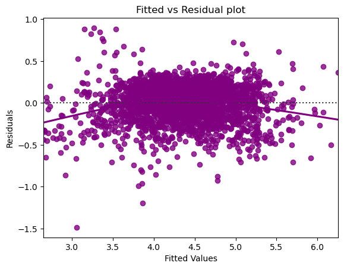

```python
# let's plot the fitted values vs residuals
sns.residplot(
    data=df_pred, x="Fitted Values", y="Residuals", color="purple", lowess=True
)
plt.xlabel("Fitted Values")
plt.ylabel("Residuals")
plt.title("Fitted vs Residual plot")
plt.show()
```

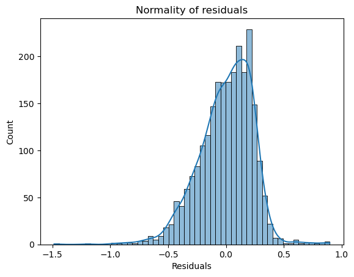

```python
#test for normality
sns.histplot(data=df_pred, x="Residuals", kde=True)
plt.title("Normality of residuals")
plt.show()
```

- the histogram of residuals is approxmately bell shaped

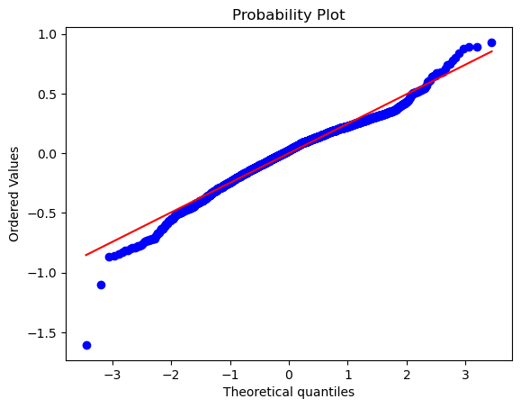

```python
# Q-Q plot
import pylab
import scipy.stats as stats

stats.probplot(df_pred["Residuals"], dist="norm", plot=pylab)
plt.show()
```

- the residuals for the Q-Q plot follow approximately a straight line

```python
stats.shapiro(df_pred["Residuals"])
```

```
ShapiroResult(statistic=0.978392481803894, pvalue=1.084487136206529e-18)
```

- the p-value is < 0.05 so the residuals are not normal per Shapiro-Wilk test.
- the assumption is satisfied as we will accept the distribution as being normal.

```python
# Heteroscedasticity check
import statsmodels.stats.api as sms
from statsmodels.compat import lzip
name = ["F statistic", "p-value"]
test = sms.het_goldfeldquandt(df_pred["Residuals"], x_train4)
lzip(name, test)
```

```
[('F statistic', 0.994833800284226), ('p-value', 0.5356945965994081)]
```

- the p-value is > 0.05 so the residuals are homoscedastic. Thus, the assumption is satisfied.

## Final Model

```python
# predictions on the test set
pred = olsmod2.predict(x_test4)
df_pred_test = pd.DataFrame({"Actual": y_test, "Predicted": pred})
df_pred_test.sample(10, random_state=1)
```

|  | Actual | Predicted |
| --- | --- | --- |
| 1995 | 4.566741 | 4.354627 |
| 2341 | 3.696103 | 4.012544 |
| 1913 | 3.592093 | 3.806089 |
| 688 | 4.306495 | 4.038043 |
| 650 | 4.522115 | 5.182079 |
| 2291 | 4.259294 | 4.354096 |
| 40 | 4.997685 | 5.332230 |
| 1884 | 3.875359 | 4.153752 |
| 2538 | 4.206631 | 4.105149 |
| 45 | 5.380450 | 5.312347 |

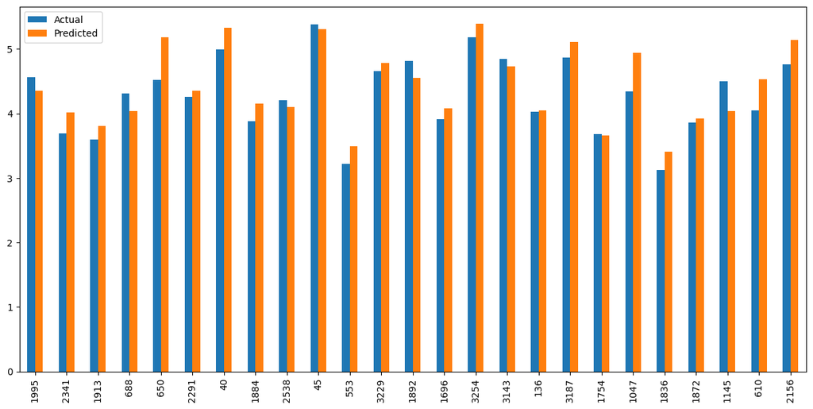

```python
df1 = df_pred_test.sample(25, random_state=1)
df1.plot(kind="bar", figsize=(15, 7))
plt.show()
```

```python
# checking model performance on train set (seen 70% data)
print("Training Performance\n")
olsmod2_train_perf = model_performance_regression(olsmod2, x_train4, y_train)
olsmod2_train_perf
```

```
Training Performance
```

|  | RMSE | MAE | R-squared | Adj. R-squared | MAPE |
| --- | --- | --- | --- | --- | --- |
| 0 | 0.250267 | 0.194949 | 0.816159 | 0.815241 | 4.694953 |

```python
# checking model performance on test set (seen 30% data)
print("Test Performance\n")
olsmod2_test_perf = model_performance_regression(olsmod2, x_test4, y_test)
olsmod2_test_perf
```

```
Test Performance
```

|  | RMSE | MAE | R-squared | Adj. R-squared | MAPE |
| --- | --- | --- | --- | --- | --- |
| 0 | 0.252815 | 0.195519 | 0.822792 | 0.820715 | 4.788388 |

```python
# training performance comparison
models_train_comp_df = pd.concat(
    [olsmodel_train_perf.T, olsmod2_train_perf.T],
    axis=1,
)
models_train_comp_df.columns = [
    "Linear Regression (all variables)",
    "Linear Regression (selected variables)",
]
print("Training performance comparison:")
models_train_comp_df
```

```
Training performance comparison:
```

|  | Linear Regression (all variables) | Linear Regression (selected variables) |
| --- | --- | --- |
| RMSE | 0.229849 | 0.250267 |
| MAE | 0.180336 | 0.194949 |
| R-squared | 0.844933 | 0.816159 |
| Adj. R-squared | 0.841723 | 0.815241 |
| MAPE | 4.326958 | 4.694953 |

```python
# test performance comparison
models_test_comp_df = pd.concat(
    [olsmodel_test_perf.T, olsmod2_test_perf.T],
    axis=1,
)
models_test_comp_df.columns = [
    "Linear Regression (all variables)",
    "Linear Regression (selected variables)",
]
print("Test performance comparison:")
models_test_comp_df
```

```
Test performance comparison:
```

|  | Linear Regression (all variables) | Linear Regression (selected variables) |
| --- | --- | --- |
| RMSE | 0.238306 | 0.252815 |
| MAE | 0.184064 | 0.195519 |
| R-squared | 0.842547 | 0.822792 |
| Adj. R-squared | 0.834731 | 0.820715 |
| MAPE | 4.488006 | 4.788388 |

```python
olsmodel_final = sm.OLS(y_train, x_train4).fit()
print(olsmodel_final.summary())
```

```
                              OLS Regression Results
=================================================================================
Dep. Variable:     normalized_used_price   R-squared:                       0.816
Model:                               OLS   Adj. R-squared:                  0.815
Method:                    Least Squares   F-statistic:                     1068.
Date:                   Fri, 10 Feb 2023   Prob (F-statistic):               0.00
Time:                           21:11:01   Log-Likelihood:                -81.485
No. Observations:                   2417   AIC:                             185.0
Df Residuals:                       2406   BIC:                             248.7
Df Model:                             10
Covariance Type:               nonrobust
========================================================================================
                           coef    std err          t      P>|t|      [0.025      0.975]
----------------------------------------------------------------------------------------
const                  -22.5463      3.360     -6.709      0.000     -29.136     -15.956
const                  -22.5463      3.360     -6.709      0.000     -29.136     -15.956
main_camera_mp           0.0147      0.001     11.101      0.000       0.012       0.017
selfie_camera_mp         0.0115      0.001     10.193      0.000       0.009       0.014
ram                      0.0146      0.005      3.085      0.002       0.005       0.024
battery               9.378e-05   4.95e-06     18.939      0.000    8.41e-05       0.000
release_year             0.0230      0.003      6.907      0.000       0.016       0.030
normalized_new_price     0.4709      0.011     42.268      0.000       0.449       0.493
brand_name_Karbonn       0.1324      0.058      2.270      0.023       0.018       0.247
brand_name_Lenovo        0.0580      0.023      2.499      0.013       0.012       0.103
brand_name_Xiaomi        0.0737      0.027      2.682      0.007       0.020       0.128
os_Others               -0.1394      0.029     -4.837      0.000      -0.196      -0.083
==============================================================================
Omnibus:                      164.060   Durbin-Watson:                   1.918
Prob(Omnibus):                  0.000   Jarque-Bera (JB):              294.411
Skew:                          -0.494   Prob(JB):                     1.17e-64
Kurtosis:                       4.395   Cond. No.                     3.52e+17
==============================================================================

Notes:
[1] Standard Errors assume that the covariance matrix of the errors is correctly specified.
[2] The smallest eigenvalue is 2.96e-25. This might indicate that there are
strong multicollinearity problems or that the design matrix is singular.
```